# Week 7 Application Exercise - KEY

Prof. Amanda D. Perez, PhD

# Introduction

For our final lab you will get the chance to practice running and interpreting analyses we’ve learned throughout the course.

We will be using the dataset `olive`. This data contains the composition in percentage of eight fatty acids found in the lipid fraction of 572 Italian olive oils sourced from J. Zupan, and J. Gasteiger. Neural Networks in Chemistry and Drug Design.

First, let’s load our packages.

```r
library(tidyverse)
library(dslabs)
```

Second, let’s take a glimpse at the data.

```r
glimpse(olive)
```

```
## Rows: 572
## Columns: 10
## $ region      <fct> Southern Italy, Southern Italy, Southern Italy, Southern I…
## $ area        <fct> North-Apulia, North-Apulia, North-Apulia, North-Apulia, No…
## $ palmitic    <dbl> 10.75, 10.88, 9.11, 9.66, 10.51, 9.11, 9.22, 11.00, 10.82,…
## $ palmitoleic <dbl> 0.75, 0.73, 0.54, 0.57, 0.67, 0.49, 0.66, 0.61, 0.60, 0.55…
## $ stearic     <dbl> 2.26, 2.24, 2.46, 2.40, 2.59, 2.68, 2.64, 2.35, 2.39, 2.13…
## $ oleic       <dbl> 78.23, 77.09, 81.13, 79.52, 77.71, 79.24, 79.90, 77.28, 77…
## $ linoleic    <dbl> 6.72, 7.81, 5.49, 6.19, 6.72, 6.78, 6.18, 7.34, 7.09, 6.33…
## $ linolenic   <dbl> 0.36, 0.31, 0.31, 0.50, 0.50, 0.51, 0.49, 0.39, 0.46, 0.26…
## $ arachidic   <dbl> 0.60, 0.61, 0.63, 0.78, 0.80, 0.70, 0.56, 0.64, 0.83, 0.52…
## $ eicosenoic  <dbl> 0.29, 0.29, 0.29, 0.35, 0.46, 0.44, 0.29, 0.35, 0.33, 0.30…
```

# Correlation

**Exercise 1:** Run a correlation between two fatty acids of your choice. Interpret the correlation.

```r
cor.test(olive$oleic, olive$palmitic)
```

```
##
##  Pearson's product-moment correlation
##
## data:  olive$oleic and olive$palmitic
## t = -36.568, df = 570, p-value < 2.2e-16
## alternative hypothesis: true correlation is not equal to 0
## 95 percent confidence interval:
##  -0.8602632 -0.8110276
## sample estimates:
##        cor
## -0.8373354
```

**Exercise 2:** Regardless of significance, create a ggplot that shows the relationship between the two variables you selected. Make sure you: color the points, add a theme, add alpha = 0.5, label the x and y axes, add a title, and add a “lm” regression line.

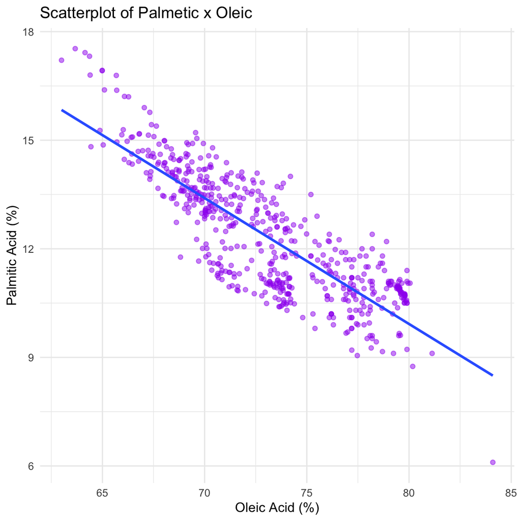

```r
library(ggplot2)
ggplot(olive, aes(oleic, palmitic)) +
  geom_point(alpha = 0.5, color = "purple") +
  labs(x = "Oleic Acid (%)", y  = "Palmitic Acid (%)",title = "Scatterplot of Palmetic x Oleic")+
  theme_minimal() +
  geom_smooth(method = "lm", se = F)
```

# T-Test

**Exercise 3:** Below I created a new dataset to use for this exercise and the next one (#4). `olive.t` adjusts the `region` variable so that it only contains two levels. Use the `region` variable in the `olive.t` dataset as the predictor variable for a t.test. Then, pick one of the 8 fatty acids as the outcome variable. Run a t.test and interpret the results.

```r
olive.t <- olive %>%
  filter(region != "Sardinia")
olive.t$region <- droplevels(olive.t$region)
levels(olive.t$region)
```

```
## [1] "Northern Italy" "Southern Italy"
```

```r
t.test(arachidic ~ region, olive.t)
```

```
##
##  Welch Two Sample t-test
##
## data:  arachidic by region
## t = -10.347, df = 170.6, p-value < 2.2e-16
## alternative hypothesis: true difference in means is not equal to 0
## 95 percent confidence interval:
##  -0.3041443 -0.2066854
## sample estimates:
## mean in group Northern Italy mean in group Southern Italy
##                    0.3757616                    0.6311765
```

**Exercise 4:** Regardless of significance, create a ggplot that shows the relationship between the region and the acid you selected. Make sure you: fill the bars differently, add a theme, label the x and y axes, and add a title.

```r
library(viridis)
```

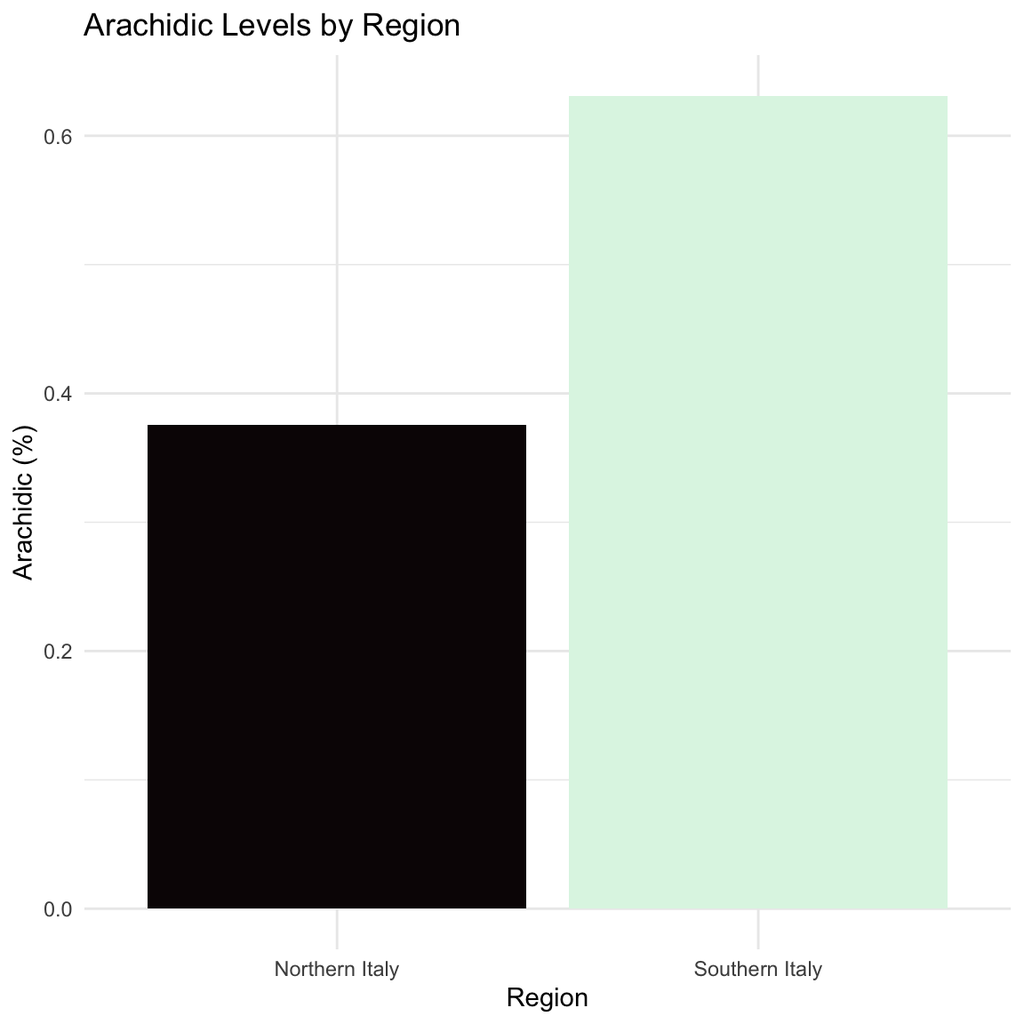

```r
ggplot(olive.t, aes(region, arachidic, fill = region)) +
  stat_summary(fun = "mean", geom = "bar") +
  scale_fill_viridis(option="mako", discrete = TRUE) +
  theme_minimal() +
  guides(fill = "none") +
  labs(title = "Arachidic Levels by Region", x = "Region", y = "Arachidic (%)")
```

# Linear Regression

**Exercise 5:**

Run a linear regression that uses the interaction of `region*linolenic` as the predictors and an acid of your choice as the outcome variable. Interpret each of the significant slopes. How is the model fit?

```r
summary(lm(arachidic ~ region*linolenic, olive))
```

```
##
## Call:
## lm(formula = arachidic ~ region * linolenic, data = olive)
##
## Residuals:
##      Min       1Q   Median       3Q      Max
## -0.63887 -0.08736 -0.01084  0.06591  0.54573
##
## Coefficients:
##                                Estimate Std. Error t value Pr(>|t|)
## (Intercept)                     0.11390    0.01863   6.113 1.82e-09 ***
## regionSardinia                  0.39506    0.07523   5.251 2.14e-07 ***
## regionSouthern Italy            0.27111    0.04236   6.400 3.27e-10 ***
## linolenic                       1.20186    0.06767  17.760  < 2e-16 ***
## regionSardinia:linolenic       -0.37956    0.27247  -1.393    0.164
## regionSouthern Italy:linolenic -0.55516    0.11896  -4.667 3.82e-06 ***
## ---
## Signif. codes:  0 '***' 0.001 '**' 0.01 '*' 0.05 '.' 0.1 ' ' 1
##
## Residual standard error: 0.14 on 566 degrees of freedom
## Multiple R-squared:  0.5999, Adjusted R-squared:  0.5964
## F-statistic: 169.7 on 5 and 566 DF,  p-value: < 2.2e-16
```

**Exercise 6:** Regardless of significance, create a ggplot that shows the relationship between the two predictors and the outcome variable you selected. Make sure you: color the points by region, add a theme, label the x and y axes, label the legend, and add a title.

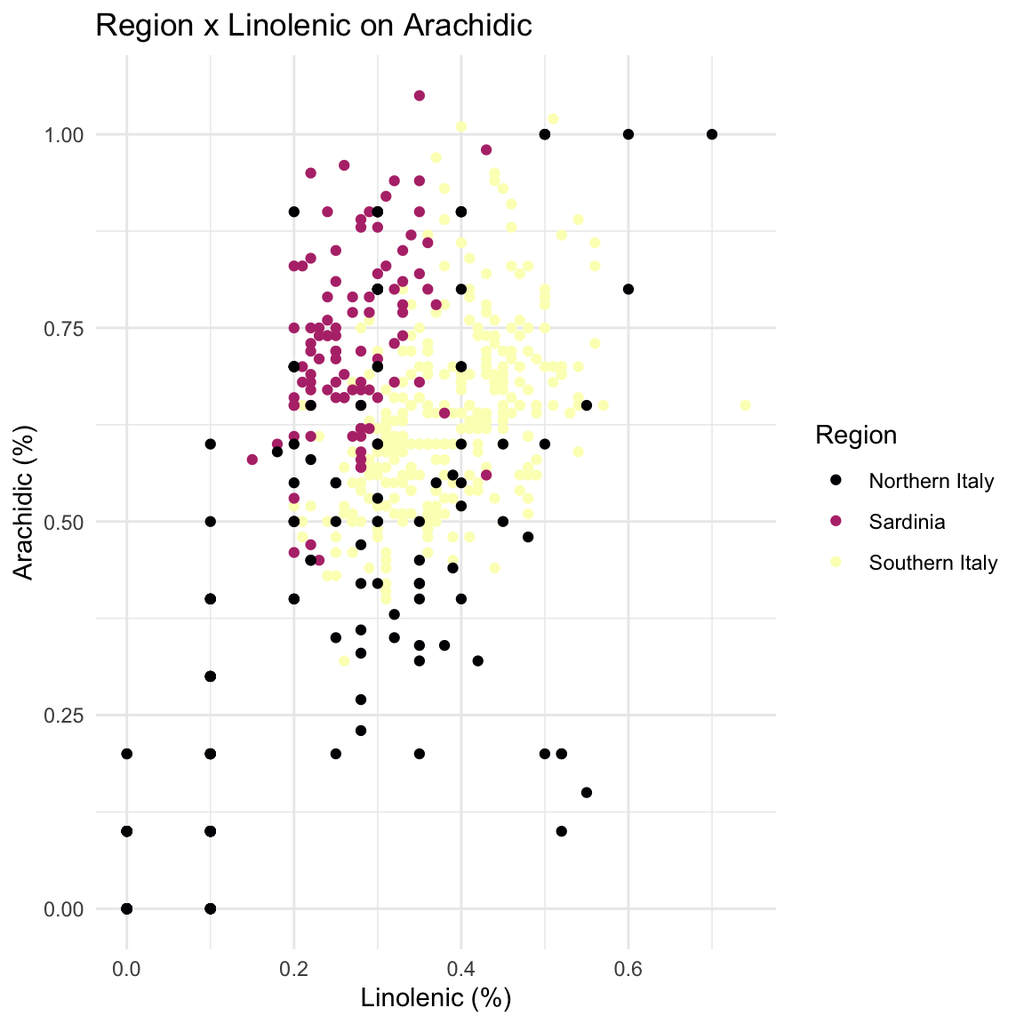

```r
ggplot(olive, aes(linolenic, arachidic, color = region)) +
  geom_point() +
  scale_color_viridis(option="magma", discrete = TRUE) +
  theme_minimal() +
  labs(title = "Region x Linolenic on Arachidic", x = "Linolenic (%)", y = "Arachidic (%)", color = "Region")
```

# Logistic Regression

**Exercise 7:** I have created a new variable below called `northern_binary`. The value is `1` if the olive oil is from Northern Italy and `0` if it is not. Your job is to run a logistic regression with `northern_binary` as the outcome variable. From the dataset, pick 4 numeric variables to add as predictors. Add them as main effects separated by “+” and do not add any interactions to the model. Interpret all significant slopes.

```r
olive <- olive %>%
  mutate(northern_binary = if_else(region == "Northern Italy", 1, 0))

mod.log <- glm(northern_binary ~ palmitic + arachidic + stearic +
                 oleic , data = olive, family = "binomial")
summary(mod.log)
```

```
##
## Call:
## glm(formula = northern_binary ~ palmitic + arachidic + stearic +
##     oleic, family = "binomial", data = olive)
##
## Deviance Residuals:
##      Min        1Q    Median        3Q       Max
## -2.42666  -0.18816  -0.06831   0.08053   2.63729
##
## Coefficients:
##              Estimate Std. Error z value Pr(>|z|)
## (Intercept) -101.1995    13.7806  -7.344 2.08e-13 ***
## palmitic       1.1486     0.2680   4.286 1.82e-05 ***
## arachidic     -5.8682     0.8357  -7.022 2.19e-12 ***
## stearic       -0.1644     0.4688  -0.351    0.726
## oleic          1.2032     0.1465   8.214  < 2e-16 ***
## ---
## Signif. codes:  0 '***' 0.001 '**' 0.01 '*' 0.05 '.' 0.1 ' ' 1
##
## (Dispersion parameter for binomial family taken to be 1)
##
##     Null deviance: 660.30  on 571  degrees of freedom
## Residual deviance: 185.21  on 567  degrees of freedom
## AIC: 195.21
##
## Number of Fisher Scoring iterations: 7
```

# Chickens!

The last part of this lab is a bit different. This time, I will describe two research questions. For each research question your job is to analyze (pick the most appropriate analysis), visualize (make sure to clean up your graph), and interpret the results in terms of the research question.

This data contains the weight of chickens. It contains 4 different diets as well as multiple time points.

```r
glimpse(ChickWeight)
```

```
## Rows: 578
## Columns: 4
## $ weight <dbl> 42, 51, 59, 64, 76, 93, 106, 125, 149, 171, 199, 205, 40, 49, 5…
## $ Time   <dbl> 0, 2, 4, 6, 8, 10, 12, 14, 16, 18, 20, 21, 0, 2, 4, 6, 8, 10, 1…
## $ Chick  <ord> 1, 1, 1, 1, 1, 1, 1, 1, 1, 1, 1, 1, 2, 2, 2, 2, 2, 2, 2, 2, 2, …
## $ Diet   <fct> 1, 1, 1, 1, 1, 1, 1, 1, 1, 1, 1, 1, 1, 1, 1, 1, 1, 1, 1, 1, 1, …
```

**Research Question 1:** Is Diet #1 the most effective diet for fattening up chickens?

```r
mod.chick <- lm(weight ~ Diet, ChickWeight)
summary(mod.chick)
```

```
##
## Call:
## lm(formula = weight ~ Diet, data = ChickWeight)
##
## Residuals:
##     Min      1Q  Median      3Q     Max
## -103.95  -53.65  -13.64   40.38  230.05
##
## Coefficients:
##             Estimate Std. Error t value Pr(>|t|)
## (Intercept)  102.645      4.674  21.961  < 2e-16 ***
## Diet2         19.971      7.867   2.538   0.0114 *
## Diet3         40.305      7.867   5.123 4.11e-07 ***
## Diet4         32.617      7.910   4.123 4.29e-05 ***
## ---
## Signif. codes:  0 '***' 0.001 '**' 0.01 '*' 0.05 '.' 0.1 ' ' 1
##
## Residual standard error: 69.33 on 574 degrees of freedom
## Multiple R-squared:  0.05348,    Adjusted R-squared:  0.04853
## F-statistic: 10.81 on 3 and 574 DF,  p-value: 6.433e-07
```

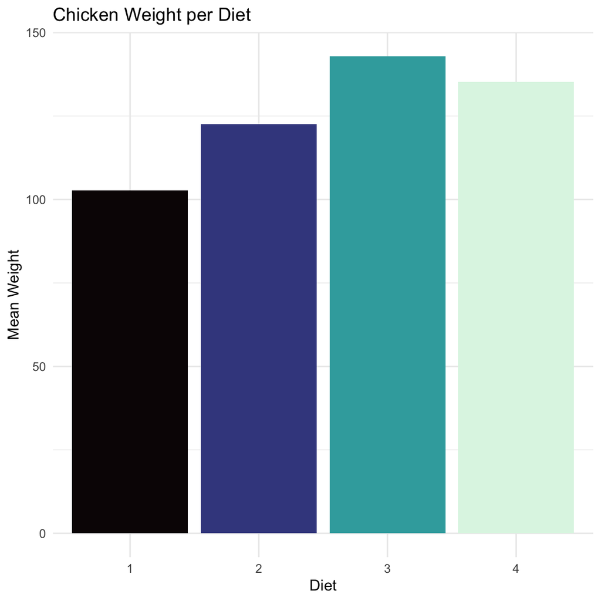

```r
ggplot(ChickWeight, aes(x = Diet, y = weight, fill = Diet)) +
  stat_summary(fun = "mean", geom = "bar") +
  theme_minimal() +
  scale_fill_viridis(option="mako", discrete = TRUE) +
  guides(fill = "none") +
  labs(title = "Chicken Weight per Diet", x = "Diet", y = "Mean Weight")
```

**Research Question 2:** Do chickens get fatter over time?

```r
cor.test(ChickWeight$Time, ChickWeight$weight)
```

```
##
##  Pearson's product-moment correlation
##
## data:  ChickWeight$Time and ChickWeight$weight
## t = 36.725, df = 576, p-value < 2.2e-16
## alternative hypothesis: true correlation is not equal to 0
## 95 percent confidence interval:
##  0.8109073 0.8599481
## sample estimates:
##       cor
## 0.8371017
```

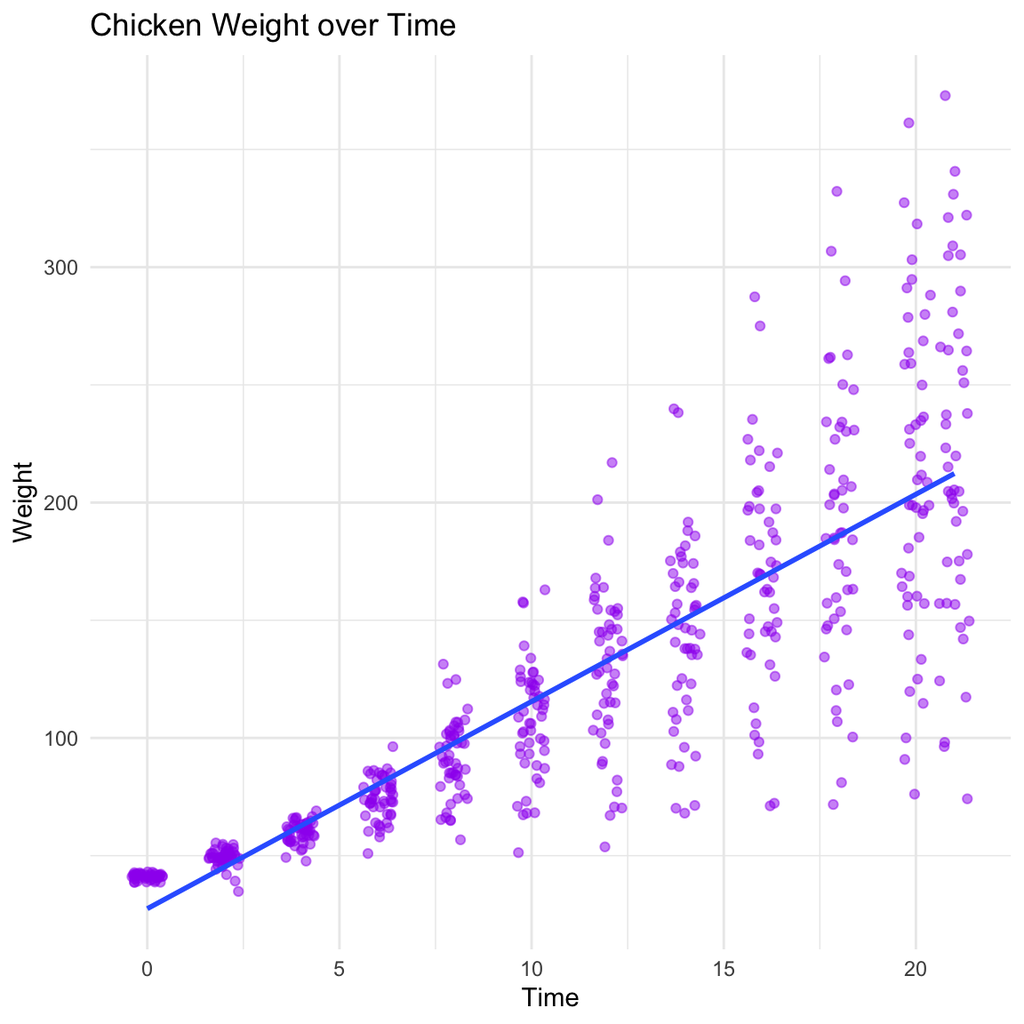

```r
ggplot(ChickWeight, aes(Time, weight)) +
  geom_point(color = "purple", alpha = 0.5, position = "jitter") +
  theme_minimal() +
  labs(title = "Chicken Weight over Time", x = "Time", y = "Weight") +
  geom_smooth(method = "lm", se = F)
```

## Data Structure

The last questions will give you practice tidying the `ChickWeight` data.

**Chicken 1:** Which chicken is the heaviest? Find the chicken and then display both the chicken # and the diet the chicken is on.

```r
max(ChickWeight$weight)
```

```
## [1] 373
```

```r
ChickWeight %>%
  as.data.frame() %>%
  filter(weight == 373) %>%
  select(Chick, Diet, weight)
```

```
##   Chick Diet weight
## 1    35    3    373
```

**Chicken 2:** What is the average chicken weight for each of the different diets?

```r
ChickWeight %>%
  group_by(Diet) %>%
  summarize(average_weight = mean(weight))
```

```
## # A tibble: 4 x 2
##   Diet  average_weight
##   <fct>          <dbl>
## 1 1               103.
## 2 2               123.
## 3 3               143.
## 4 4               135.
```

**Chicken 3:** Create a new variable that changes the diet labeling as follows: 1 = A, 2 = B, 3 = C, 4 = D

```r
ChickWeight <- ChickWeight %>%
  mutate(Diet= fct_recode(Diet,
  "A" = "1",
  "B" = "2",
  "C" = "3",
  "D" = "4"))

levels(ChickWeight$Diet)
```

```
## [1] "A" "B" "C" "D"
```

**Chicken 4:** Display the heaviest chicken weight per diet.

```r
ChickWeight %>%
  group_by(Diet) %>%
  summarize(heaviest_chicken = max(weight))
```

```
## # A tibble: 4 x 2
##   Diet  heaviest_chicken
##   <fct>            <dbl>
## 1 A                  305
## 2 B                  331
## 3 C                  373
## 4 D                  322
```

**Chicken 5:** What kind of distribution does the weight variable have? Then, apply a log transformation and view the distribution again. How did the distribution change? **Note: For this question you will need to create a histogram to view the distribution**

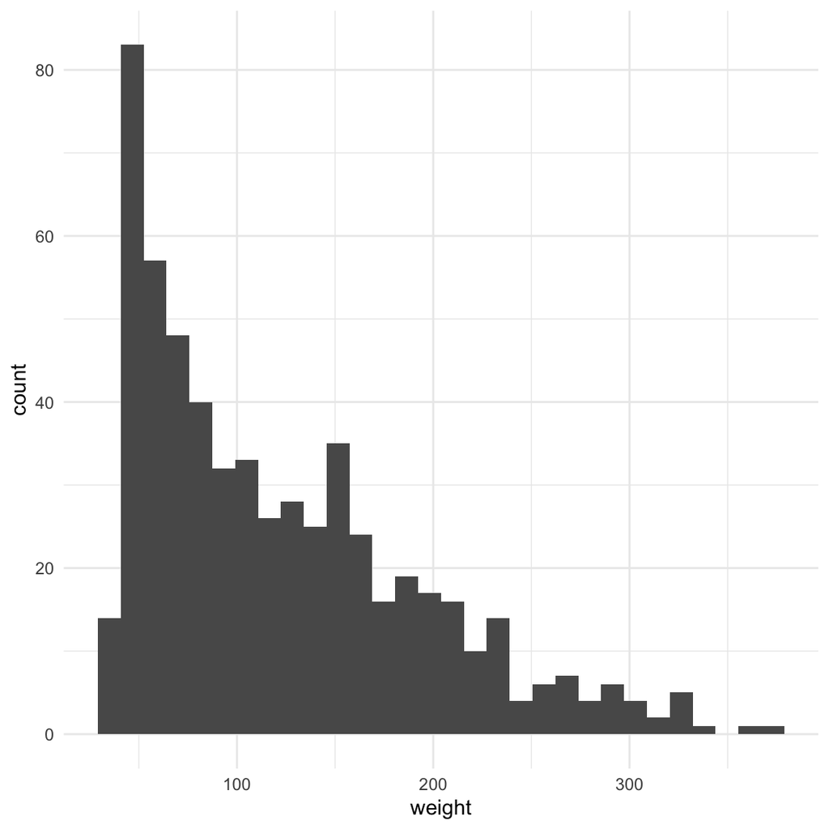

```r
ggplot(ChickWeight, aes(weight)) +
  geom_histogram() +
  theme_minimal()
```

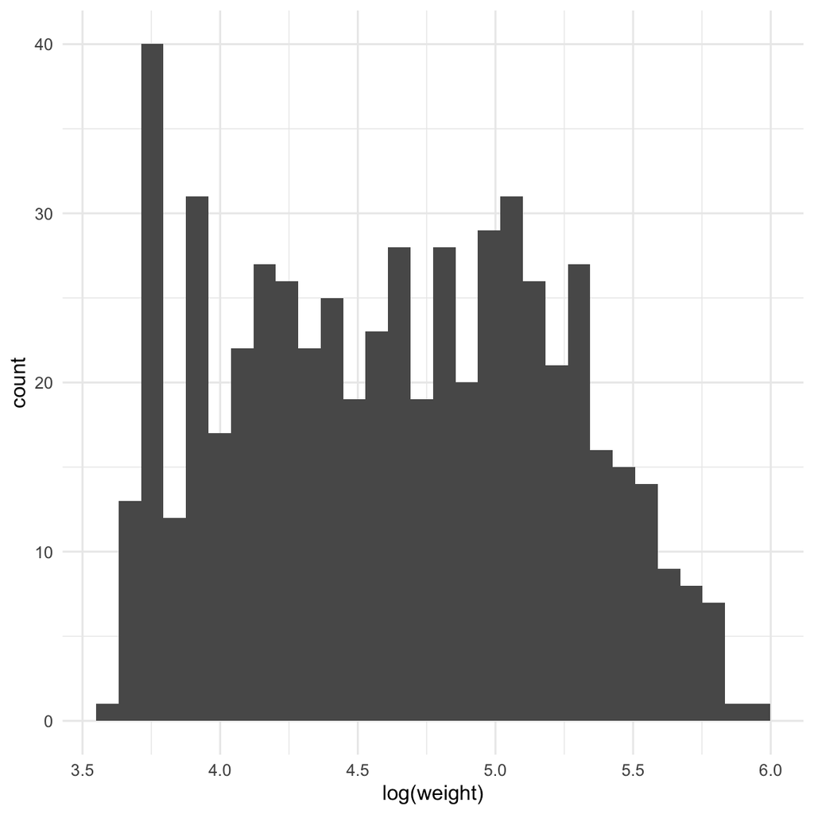

```r
ggplot(ChickWeight, aes(log(weight))) +
  geom_histogram() +
  theme_minimal()
```